```python
import numpy as np
import numpy.linalg as LA
import scipy.linalg as la
import matplotlib.pyplot as plt
```

# Project 1 SVD

The singular value decomposition (SVD) of an $m\times d$ matrix $A$ is a factorization of the form

\begin{equation}\label{eq1}\tag{1} A=V\Sigma U^T \end{equation}

where $V$ is an $m\times m$ orthogonal matrix and $U$ is a $d\times d$ orthogonal matrix. $\Sigma$ is an $m\times d$ diagonal matrix with nonnegative real numbers $\sigma_i$ on the diagonal.

Alternatively this expresses $A$ as a sum of rank 1 matrices

\begin{equation}\label{eq2}\tag{2} A=\sum_{i=1}^r \sigma_i \mathbf{v}_i\mathbf{u}_i^T \end{equation}

where $\sigma_i$ $i=1,...,r$ are the positive diagonal entries of $\Sigma$ and $\mathbf{v}_i, \mathbf{u}_i$ are the $i$th column vectors of $V$ and $U$, respectively.

# Problems

**Parts (a)-(c) can be handwritten somewhere else and attached as a separate file (or typed in Latex). If you know how to type Latex within a Jupyter notebook, you are welcome to type it here as long as its done in Latex notation.**

#### a) [5pt]

Show that the columns of $U$ form an orthonormal basis in $\mathbb{R}^d$ of eigenvectors of $A^TA$. Show that the columns of $V$ form an orthonormal basis in $\mathbb{R}^n$ of eigenvectors of $AA^T$.

#### b) [5pt]

Use the fact that $U^T A^T AU=\Sigma^T \Sigma$ to show that

\begin{equation}\label{eq3}\tag{3} U_1^T A^T AU_1=\Sigma_1^2 \end{equation}

where $U_1=[\mathbf{u}_1\;\, \mathbf{u}_2 \cdots \mathbf{u}_r]$ and $\Sigma_1$ is the $r\times r$ diagonal matrix with all positive $\sigma_i$ on the diagonal. How does one find the $m\times r$ matrix

$$V_1=[\mathbf{v}_1\;\, \mathbf{v}_2 \cdots \mathbf{v}_r]$$

based on $A$, $U_1$ and $\Sigma_1$?

#### c) [20pt]

(Two simple examples) With

$$ A_1= \begin{bmatrix} 2 & 1\\ 1 & 2 \end{bmatrix} $$

and $$ A_2= \begin{bmatrix} 2 & 1/2\\ 2 & 2 \end{bmatrix} $$

find the eigenvectors and eigenvalues of $A_1$ and $A_2$. Find matrices $C_1$ and $C_2$ such that

\begin{equation} A_i=C_i \Sigma_i C_i^{-1}\;\;\; i=1,2. \end{equation}

Use this decomposition to write $A_1$ and $A_2$ as a sum of rank 1 matrices. Find the SVD of $A_1$ and $A_2$. Can you explain the differences (and similarities) to what you found above?

#### d) [50 pts]

Write a python function to perform the singular value decomposition, based on the QR algorithm applied to $A^T A$. You may use Hessenberg from (la.hessenberg) and QR decomposition in the scipy.linalg module. Type help(la.hessenberg) and help(la.qr) for more details. The function should return the matrices $U_1, V_1$ and $\Sigma_1$. (No credit if you use the la.svd directly!)

#### e) [10 pts]

As a modification, try to shift the QR algorithm. That is, instead of

\begin{equation} H^{(0)}=Q_0 R_0 \rightarrow H^{(1)}=R_0 Q_0, \end{equation}

iterate this time on $H^{(0)}-\tau I$:

\begin{equation} H^{(0)}-\tau I=Q_0 R_0 \rightarrow H^{(1)}=R_0 Q_0+\tau I. \end{equation}

You may, for instance start with

\begin{equation} \tau= H_{dd}^{0} \end{equation}

and change to $H_{d-1 d-1}^{k}$ when the off diagonal elements of the $d$th row of $H^{(k)}$ ($H_{d d-1}^{k}$) are sufficiently small, and so on...

#### f) [10 pts]

Load the file image.npy as the matrix $A$ (this is a pixel image of the digit 3). Use the python function from d) (or e)) to find

\begin{equation}\label{eq4}\tag{4} A_k=\sum_{i=1}^k \sigma_i \mathbf{v}_i\mathbf{u}_i^T\;\;k=4, 10 \text{ and } r \end{equation}

and plot the corresponding images for each value of $k$ used.

Here $\sigma_i$ $i=1,...,r$ are the positive singular values in decreasing order. Calculate the Frobenius norm of $A-A_k$ for $k=4, 10$ and $r$. You may use a Python built-in function to compute the Frobenius norm. The Frobenius norm of matrix $A$ is defined as $$ \| A \|_F = \sqrt{\sum_{i,j=1}^{i=m,j=d} a_{ij}^2}. $$

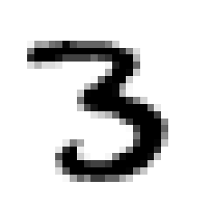

```python
A = np.load('image.npy')
plt.imshow(A, cmap="binary")
plt.axis("off")
plt.show()
```